# BIS 15L Midterm 2

Benjamin Prieto

## Instructions

Answer the following questions and complete the exercises in RMarkdown. Please embed all of your code and push your final work to your repository. Your code should be organized, clean, and run free from errors. Be sure to **add your name** to the author header above. You may use any resources to answer these questions (including each other), but you may not post questions to Open Stacks or external help sites. There are 10 total questions.

Make sure to use the formatting conventions of RMarkdown to make your report neat and clean! Your plots should use consistent aesthetics throughout.

This exam is due by **12:00p on Tuesday, February 22**.

## Gapminder

For this assignment, we are going to use data from [gapminder](https://www.gapminder.org/). Gapminder includes information about economics, population, social issues, and life expectancy from countries all over the world. We will use three data sets, so please load all three as separate objects.

1. population_total.csv
2. income_per_person_gdppercapita_ppp_inflation_adjusted.csv
3. life_expectancy_years.csv

```r
population <- read.csv("data/population_total.csv")
economy <- read.csv("data/income_per_person_gdppercapita_ppp_inflation_adjusted.csv")
life_exp <- read.csv("data/life_expectancy_years.csv")
```

**1. (3 points) Once you have an idea of the structure of the data, please make each data set tidy (hint: think back to pivots) and store them as new objects. You will need both the original (wide) and tidy (long) data!**

Setup

```r
library("tidyverse") #load packages
```

```r
library("ggplot2")
library("ggthemes")
```

```r
options(scipen=999) #cancel scientific notation
```

`population` Overview and Tidying

```r
glimpse(population)
```

```
## Rows: 195
## Columns: 302
## $ country <chr> "Afghanistan", "Albania", "Algeria", "Andorra", "Angola", "Ant…
## $ X1800   <int> 3280000, 400000, 2500000, 2650, 1570000, 37000, 534000, 413000…
## $ X1801   <int> 3280000, 402000, 2510000, 2650, 1570000, 37000, 520000, 413000…
## $ X1802   <int> 3280000, 404000, 2520000, 2650, 1570000, 37000, 506000, 413000…
## $ X1803   <int> 3280000, 405000, 2530000, 2650, 1570000, 37000, 492000, 413000…
## $ X1804   <int> 3280000, 407000, 2540000, 2650, 1570000, 37000, 479000, 413000…
## $ X1805   <int> 3280000, 409000, 2550000, 2650, 1570000, 37000, 466000, 413000…
## $ X1806   <int> 3280000, 411000, 2560000, 2650, 1570000, 37000, 453000, 413000…
## $ X1807   <int> 3280000, 413000, 2560000, 2650, 1570000, 37000, 441000, 413000…
## $ X1808   <int> 3280000, 414000, 2570000, 2650, 1570000, 37000, 429000, 413000…
## $ X1809   <int> 3280000, 416000, 2580000, 2650, 1570000, 37000, 417000, 413000…
## $ X1810   <int> 3280000, 418000, 2590000, 2650, 1570000, 37000, 420000, 413000…
## $ X1811   <int> 3280000, 420000, 2600000, 2650, 1570000, 37000, 422000, 413000…
```

[output cut: 289 more lines]

```r
population_long <- population %>%
  pivot_longer(cols = contains("X"), names_to = "year", values_to = "population") %>%
  separate(year, into = c("var1", "year"), sep = "X") %>%
  select(-var1)
population_long
```

```
## # A tibble: 58,695 × 3
##    country     year  population
##    <chr>       <chr>      <int>
##  1 Afghanistan 1800     3280000
##  2 Afghanistan 1801     3280000
##  3 Afghanistan 1802     3280000
##  4 Afghanistan 1803     3280000
##  5 Afghanistan 1804     3280000
##  6 Afghanistan 1805     3280000
##  7 Afghanistan 1806     3280000
##  8 Afghanistan 1807     3280000
##  9 Afghanistan 1808     3280000
## 10 Afghanistan 1809     3280000
## # … with 58,685 more rows
```

`economy` Overview and Tidying

```r
glimpse(economy)
```

```
## Rows: 193
## Columns: 242
## $ country <chr> "Afghanistan", "Albania", "Algeria", "Andorra", "Angola", "Ant…
## $ X1800   <int> 603, 667, 715, 1200, 618, 757, 1640, 514, 817, 1850, 775, 1450…
## $ X1801   <int> 603, 667, 716, 1200, 620, 757, 1640, 514, 822, 1850, 775, 1450…
## $ X1802   <int> 603, 667, 717, 1200, 623, 757, 1650, 514, 826, 1860, 775, 1450…
## $ X1803   <int> 603, 667, 718, 1200, 626, 757, 1650, 514, 831, 1870, 775, 1450…
## $ X1804   <int> 603, 667, 719, 1210, 628, 757, 1660, 514, 836, 1880, 775, 1450…
## $ X1805   <int> 603, 668, 720, 1210, 631, 757, 1660, 514, 841, 1880, 776, 1450…
## $ X1806   <int> 603, 668, 721, 1210, 634, 757, 1670, 514, 845, 1890, 776, 1450…
## $ X1807   <int> 603, 668, 722, 1210, 637, 758, 1680, 514, 850, 1900, 776, 1450…
## $ X1808   <int> 603, 668, 723, 1220, 640, 758, 1680, 514, 855, 1910, 776, 1450…
## $ X1809   <int> 603, 668, 724, 1220, 642, 758, 1690, 514, 860, 1920, 776, 1450…
## $ X1810   <int> 604, 668, 725, 1220, 645, 758, 1690, 514, 865, 1920, 777, 1450…
## $ X1811   <int> 604, 668, 726, 1220, 648, 758, 1700, 515, 869, 1940, 777, 1450…
```

[output cut: 229 more lines]

```r
economy_long <- economy %>%
  pivot_longer(cols = contains("X"), names_to = "year", values_to = "income_per_person_gdppercapita_ppp_inflation_adjusted") %>%
  separate(year, into = c("var1", "year"), sep = "X") %>%
  select(-var1)
economy_long
```

```
## # A tibble: 46,513 × 3
##    country     year  income_per_person_gdppercapita_ppp_inflation_adjusted
##    <chr>       <chr>                                                 <int>
##  1 Afghanistan 1800                                                    603
##  2 Afghanistan 1801                                                    603
##  3 Afghanistan 1802                                                    603
##  4 Afghanistan 1803                                                    603
##  5 Afghanistan 1804                                                    603
##  6 Afghanistan 1805                                                    603
##  7 Afghanistan 1806                                                    603
##  8 Afghanistan 1807                                                    603
##  9 Afghanistan 1808                                                    603
## 10 Afghanistan 1809                                                    603
## # … with 46,503 more rows
```

`life_exp` Overview and Tidying

```r
glimpse(life_exp)
```

```
## Rows: 187
## Columns: 302
## $ country <chr> "Afghanistan", "Albania", "Algeria", "Andorra", "Angola", "Ant…
## $ X1800   <dbl> 28.2, 35.4, 28.8, NA, 27.0, 33.5, 33.2, 34.0, 34.0, 34.4, 29.2…
## $ X1801   <dbl> 28.2, 35.4, 28.8, NA, 27.0, 33.5, 33.2, 34.0, 34.0, 34.4, 29.2…
## $ X1802   <dbl> 28.2, 35.4, 28.8, NA, 27.0, 33.5, 33.2, 34.0, 34.0, 34.4, 29.2…
## $ X1803   <dbl> 28.2, 35.4, 28.8, NA, 27.0, 33.5, 33.2, 34.0, 34.0, 34.4, 29.2…
## $ X1804   <dbl> 28.2, 35.4, 28.8, NA, 27.0, 33.5, 33.2, 34.0, 34.0, 34.4, 29.2…
## $ X1805   <dbl> 28.2, 35.4, 28.8, NA, 27.0, 33.5, 33.2, 34.0, 34.0, 34.4, 29.2…
## $ X1806   <dbl> 28.1, 35.4, 28.8, NA, 27.0, 33.5, 33.2, 34.0, 34.0, 34.4, 29.2…
## $ X1807   <dbl> 28.1, 35.4, 28.8, NA, 27.0, 33.5, 33.2, 34.0, 34.0, 34.4, 29.2…
## $ X1808   <dbl> 28.1, 35.4, 28.8, NA, 27.0, 33.5, 33.2, 34.0, 34.0, 34.4, 29.2…
## $ X1809   <dbl> 28.1, 35.4, 28.8, NA, 27.0, 33.5, 33.2, 34.0, 34.0, 34.4, 29.2…
## $ X1810   <dbl> 28.1, 35.4, 28.8, NA, 27.0, 33.5, 33.2, 34.0, 34.0, 34.4, 29.2…
## $ X1811   <dbl> 28.1, 35.4, 28.8, NA, 27.0, 33.5, 33.2, 34.0, 34.0, 34.4, 29.2…
```

[output cut: 289 more lines]

```r
life_exp_long <- life_exp %>%
  pivot_longer(cols = contains("X"), names_to = "year", values_to = "life_expectancy_years") %>%
  separate(year, into = c("var1", "year"), sep = "X") %>%
  select(-var1)
life_exp_long
```

```
## # A tibble: 56,287 × 3
##    country     year  life_expectancy_years
##    <chr>       <chr>                 <dbl>
##  1 Afghanistan 1800                   28.2
##  2 Afghanistan 1801                   28.2
##  3 Afghanistan 1802                   28.2
##  4 Afghanistan 1803                   28.2
##  5 Afghanistan 1804                   28.2
##  6 Afghanistan 1805                   28.2
##  7 Afghanistan 1806                   28.1
##  8 Afghanistan 1807                   28.1
##  9 Afghanistan 1808                   28.1
## 10 Afghanistan 1809                   28.1
## # … with 56,277 more rows
```

**2. (1 point) How many different countries are represented in the data? Provide the total number and their names. Since each data set includes different numbers of countries, you will need to do this for each one.**

`population`

```r
population %>%
  summarize(n_countries = n_distinct(country))
```

```
##   n_countries
## 1         195
```

```r
population %>%
  select(country)
```

```
##                            country
## 1                      Afghanistan
## 2                          Albania
## 3                          Algeria
## 4                          Andorra
## 5                           Angola
## 6              Antigua and Barbuda
## 7                        Argentina
## 8                          Armenia
## 9                        Australia
## 10                         Austria
## 11                      Azerbaijan
## 12                         Bahamas
## 13                         Bahrain
## 14                      Bangladesh
```

[output cut: 181 more lines]

`economy`

```r
economy %>%
  summarize(n_countries = n_distinct(country))
```

```
##   n_countries
## 1         193
```

```r
economy %>%
  select(country)
```

```
##                            country
## 1                      Afghanistan
## 2                          Albania
## 3                          Algeria
## 4                          Andorra
## 5                           Angola
## 6              Antigua and Barbuda
## 7                        Argentina
## 8                          Armenia
## 9                        Australia
## 10                         Austria
## 11                      Azerbaijan
## 12                         Bahamas
## 13                         Bahrain
## 14                      Bangladesh
```

[output cut: 179 more lines]

`life_exp`

```r
life_exp %>%
  summarize(n_countries = n_distinct(country))
```

```
##   n_countries
## 1         187
```

```r
life_exp %>%
  select(country)
```

```
##                            country
## 1                      Afghanistan
## 2                          Albania
## 3                          Algeria
## 4                          Andorra
## 5                           Angola
## 6              Antigua and Barbuda
## 7                        Argentina
## 8                          Armenia
## 9                        Australia
## 10                         Austria
## 11                      Azerbaijan
## 12                         Bahamas
## 13                         Bahrain
## 14                      Bangladesh
```

[output cut: 173 more lines]

## Life Expectancy

**3. (2 points) Let’s limit the data to 100 years (1920-2020). For these years, which country has the highest average life expectancy? How about the lowest average life expectancy?**

Highest Average Life Expectancy (1920-2020)

```r
life_exp_long %>%
  filter(between(year, 1920, 2020)) %>%
  group_by(country) %>%
  summarize(avg_life_expectancy_years = mean(life_expectancy_years, na.rm = T)) %>%
  top_n(n = 1)
```

```
## # A tibble: 1 × 2
##   country avg_life_expectancy_years
##   <chr>                       <dbl>
## 1 Andorra                      79.8
```

Lowest Average Life Expectancy (1920-2020)

```r
life_exp_long %>%
  filter(between(year, 1920, 2020)) %>%
  group_by(country) %>%
  summarize(avg_life_expectancy_years = mean(life_expectancy_years, na.rm = T)) %>%
  arrange(avg_life_expectancy_years) %>%
  head(n = 1)
```

```
## # A tibble: 1 × 2
##   country                  avg_life_expectancy_years
##   <chr>                                        <dbl>
## 1 Central African Republic                      41.8
```

**4. (3 points) Although we can see which country has the highest life expectancy for the past 100 years, we don’t know which countries have changed the most. What are the top 5 countries that have experienced the biggest improvement in life expectancy between 1920-2020?**

```r
life_exp_long %>%
  filter(year == 1920 | year == 2020) %>%
  group_by(country) %>%
  summarize(life_expectancy_change_years = max(life_expectancy_years) - min(life_expectancy_years)) %>%
  top_n(n = 5) %>%
  arrange(desc(life_expectancy_change_years))
```

```
## # A tibble: 5 × 2
##   country         life_expectancy_change_years
##   <chr>                                  <dbl>
## 1 Kuwait                                  56.8
## 2 Kyrgyz Republic                         56.5
## 3 Turkmenistan                            55.3
## 4 South Korea                             55
## 5 Tajikistan                              54.3
```

**5. (3 points) Make a plot that shows the change over the past 100 years for the country with the biggest improvement in life expectancy. Be sure to add appropriate aesthetics to make the plot clean and clear. Once you have made the plot, do a little internet searching and see if you can discover what historical event may have contributed to this remarkable change.**

[figure not shown]

```r
life_exp_long %>%
  filter(country == "Kuwait",
         between(year, 1920, 2020)) %>%
  ggplot(aes(x = as.numeric(year), y = life_expectancy_years))+
  geom_line()+
  labs(x = "Year",
       y = "Life Expectancy (years)",
       title = "Life Expectancy in Kuwait over Time (1922-2022)")+
  theme_linedraw()+
  theme(plot.title = element_text(hjust = 0.5))
```

Beginning around 1946, Kuwait experienced a large boost to their economy due to the country’s export of oil as the resource became more valuable worldwide with urbanization. As a result, Kuwait experienced greater urban development and raised public health standards and available services. [“Kuwait’s Modernity Between Memory and Forgetting”](https://www.academia.edu/8186917)

## Population Growth

**6. (3 points) Which 5 countries have had the highest population growth over the past 100 years (1920-2020)?**

```r
population_long %>%
  group_by(country) %>%
  filter(year == 1920 | year == 2020) %>%
  summarize(population_growth = max(population) - min(population)) %>%
  top_n(n = 5) %>%
  arrange(desc(population_growth))
```

```
## # A tibble: 5 × 2
##   country       population_growth
##   <chr>                     <int>
## 1 India                1063000000
## 2 China                 968000000
## 3 Indonesia             226700000
## 4 United States         220000000
## 5 Pakistan              199300000
```

**7. (4 points) Produce a plot that shows the 5 countries that have had the highest population growth over the past 100 years (1920-2020). Which countries appear to have had exponential growth?**

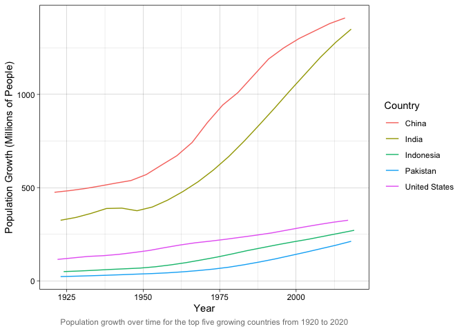

```r
population_long %>%
  filter(country == c("India", "China", "Indonesia", "United States", "Pakistan"), between(year, 1920, 2020)) %>%
  ggplot(aes(x = as.numeric(year), y = population/(10^6), color = country))+
  geom_line()+
  labs(x = "Year",
       y = "Population Growth (Millions of People)",
       caption = "Population growth over time for the top five growing countries from 1920 to 2020",
       color = "Country")+
  theme_linedraw()+
  theme(plot.caption = element_text(color = "gray50", hjust = 0.5))
```

It appears that China and India have had exponential growth in their population from 1920-2022.

## Income

The units used for income are gross domestic product per person adjusted for differences in purchasing power in international dollars.  
**8. (4 points) As in the previous questions, which countries have experienced the biggest growth in per person GDP. Show this as a table and then plot the changes for the top 5 countries. With a bit of research, you should be able to explain the dramatic downturns of the wealthiest economies that occurred during the 1980’s.**  
From Beginning to End

```r
economy_long %>%
  group_by(country) %>%
  filter(between(year, 1920, 2022)) %>%
  summarize(gdp_per_capita_change = max(income_per_person_gdppercapita_ppp_inflation_adjusted) - min(income_per_person_gdppercapita_ppp_inflation_adjusted)) %>%
  arrange(desc(gdp_per_capita_change))
```

```
## # A tibble: 193 × 2
##    country              gdp_per_capita_change
##    <chr>                                <int>
##  1 United Arab Emirates                177840
##  2 Qatar                               176920
##  3 Brunei                              163870
##  4 Kuwait                              141560
##  5 Luxembourg                           92170
##  6 Singapore                            90460
##  7 San Marino                           87520
##  8 Ireland                              71980
##  9 Norway                               60920
## 10 Saudi Arabia                         60210
## # … with 183 more rows
```

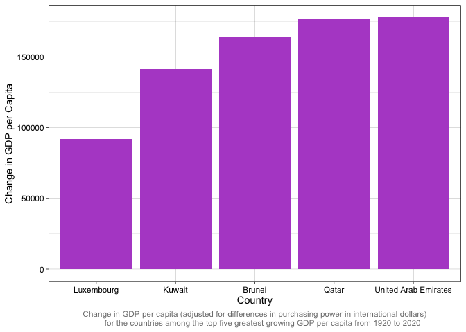

```r
economy_long %>%
  group_by(country) %>%
  filter(between(year, 1920, 2022)) %>%
  summarize(gdp_per_capita_change = max(income_per_person_gdppercapita_ppp_inflation_adjusted) - min(income_per_person_gdppercapita_ppp_inflation_adjusted)) %>%
  arrange(desc(gdp_per_capita_change)) %>%
  top_n(n = 5) %>%
  ggplot(aes(x = reorder(country, gdp_per_capita_change), y = gdp_per_capita_change))+
  geom_col(fill = "mediumorchid3")+
  labs(x = "Country",
       y = "Change in GDP per Capita",
       caption = "Change in GDP per capita (adjusted for differences in purchasing power in international dollars)
       for the countries among the top five greatest growing GDP per capita from 1920 to 2020")+
  theme_linedraw()+
  theme(plot.caption = element_text(color = "gray50", hjust = 0.5))
```

Over Time

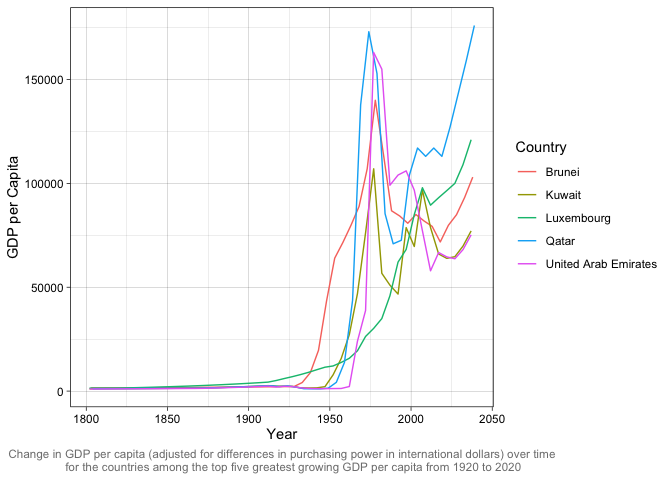

```r
economy_long %>%
  filter(country == c("Luxembourg", "Kuwait", "Brunei", "Qatar", "United Arab Emirates")) %>%
  ggplot(aes(x = as.numeric(year), y = income_per_person_gdppercapita_ppp_inflation_adjusted, color = country))+
  geom_line()+
  labs(x = "Year",
       y = "GDP per Capita",
       caption = "Change in GDP per capita (adjusted for differences in purchasing power in international dollars) over time
       for the countries among the top five greatest growing GDP per capita from 1920 to 2020",
       color = "Country")+
  theme_linedraw()+
  theme(plot.caption = element_text(color = "gray50", hjust = 0.5))
```

In the early 1980s, there was a global recession due to a major disruption to the oil supply (1979 energy crisis) caused by the Iranian Revolution, leading to a drastic increase in oil prices and high inflation. [“Early 1980s recession”](https://en.wikipedia.org/wiki/Early_1980s_recession)  
**9. (3 points) Create three new objects that restrict each data set (life expectancy, population, income) to the years 1920-2020. Hint: I suggest doing this with the long form of your data. Once this is done, merge all three data sets using the code I provide below. You may need to adjust the code depending on how you have named your objects. I called mine `life_expectancy_100`, `population_100`, and `income_100`. For some of you, learning these `joins` will be important for your project.**

```r
population_100 <- population_long %>%
  filter(between(year, 1920, 2020))
population_100
```

```
## # A tibble: 19,695 × 3
##    country     year  population
##    <chr>       <chr>      <int>
##  1 Afghanistan 1920    10600000
##  2 Afghanistan 1921    10500000
##  3 Afghanistan 1922    10300000
##  4 Afghanistan 1923     9710000
##  5 Afghanistan 1924     9200000
##  6 Afghanistan 1925     8720000
##  7 Afghanistan 1926     8260000
##  8 Afghanistan 1927     7830000
##  9 Afghanistan 1928     7420000
## 10 Afghanistan 1929     7100000
## # … with 19,685 more rows
```

```r
life_expectancy_100 <- life_exp_long %>%
  filter(between(year, 1920, 2020))
life_expectancy_100
```

```
## # A tibble: 18,887 × 3
##    country     year  life_expectancy_years
##    <chr>       <chr>                 <dbl>
##  1 Afghanistan 1920                   30.6
##  2 Afghanistan 1921                   30.7
##  3 Afghanistan 1922                   30.8
##  4 Afghanistan 1923                   30.8
##  5 Afghanistan 1924                   30.9
##  6 Afghanistan 1925                   31
##  7 Afghanistan 1926                   31
##  8 Afghanistan 1927                   31.1
##  9 Afghanistan 1928                   31.1
## 10 Afghanistan 1929                   31.2
## # … with 18,877 more rows
```

```r
income_100 <- economy_long %>%
  filter(between(year, 1920, 2020))
income_100
```

```
## # A tibble: 19,493 × 3
##    country     year  income_per_person_gdppercapita_ppp_inflation_adjusted
##    <chr>       <chr>                                                 <int>
##  1 Afghanistan 1920                                                   1490
##  2 Afghanistan 1921                                                   1520
##  3 Afghanistan 1922                                                   1550
##  4 Afghanistan 1923                                                   1570
##  5 Afghanistan 1924                                                   1600
##  6 Afghanistan 1925                                                   1630
##  7 Afghanistan 1926                                                   1650
##  8 Afghanistan 1927                                                   1680
##  9 Afghanistan 1928                                                   1710
## 10 Afghanistan 1929                                                   1740
## # … with 19,483 more rows
```

```r
gapminder_join <- inner_join(life_expectancy_100, population_100, by= c("country", "year"))
gapminder_join <- inner_join(gapminder_join, income_100, by= c("country", "year"))
gapminder_join
```

```
## # A tibble: 18,887 × 5
##    country     year  life_expectancy_years population income_per_person_gdpperc…
##    <chr>       <chr>                 <dbl>      <int>                      <int>
##  1 Afghanistan 1920                   30.6   10600000                       1490
##  2 Afghanistan 1921                   30.7   10500000                       1520
##  3 Afghanistan 1922                   30.8   10300000                       1550
##  4 Afghanistan 1923                   30.8    9710000                       1570
##  5 Afghanistan 1924                   30.9    9200000                       1600
##  6 Afghanistan 1925                   31      8720000                       1630
##  7 Afghanistan 1926                   31      8260000                       1650
##  8 Afghanistan 1927                   31.1    7830000                       1680
##  9 Afghanistan 1928                   31.1    7420000                       1710
## 10 Afghanistan 1929                   31.2    7100000                       1740
## # … with 18,877 more rows
```

**10. (4 points) Use the joined data to perform an analysis of your choice. The analysis should include a comparison between two or more of the variables `life_expectancy`, `population`, or `income.`**

How has life expectancy from 1920-2020 changed with GDP per capita for countries with the top 5 and bottom 5 growth in GDP per capita from 1920-2020?

Breakdown filter: 1920-2020, top and bottom 5 countries by GDP per capita growth dependent variable, y: life expectancy independent variable, x: GDP per capita

Top 5 Countries

```r
gapminder_join %>%
  group_by(country) %>%
  filter(between(year, 1920, 2020)) %>%
  summarize(gdp_growth = max(income_per_person_gdppercapita_ppp_inflation_adjusted) - min(income_per_person_gdppercapita_ppp_inflation_adjusted)) %>%
  top_n(n = 5) %>%
  arrange(desc(gdp_growth))
```

```
## # A tibble: 5 × 2
##   country              gdp_growth
##   <chr>                     <int>
## 1 United Arab Emirates     177840
## 2 Qatar                    176920
## 3 Brunei                   163870
## 4 Kuwait                   141560
## 5 Luxembourg                92170
```

```r
top_5 <- gapminder_join %>%
  filter(country == c("United Arab Emirates","Qatar","Brunei","Kuwait",
                      "Luxembourg")) %>%
  select(-population, -year)
top_5
```

```
## # A tibble: 101 × 3
##    country life_expectancy_years income_per_person_gdppercapita_ppp_inflation_a…
##    <chr>                   <dbl>                                           <int>
##  1 Brunei                   36.3                                            2160
##  2 Brunei                   39.6                                            2210
##  3 Brunei                   42.8                                            4120
##  4 Brunei                   46                                              8900
##  5 Brunei                   49.2                                           19600
##  6 Brunei                   52.4                                           43500
##  7 Brunei                   55                                             64000
##  8 Brunei                   57.7                                           71500
##  9 Brunei                   60.2                                           79800
## 10 Brunei                   62.1                                           88900
## # … with 91 more rows
```

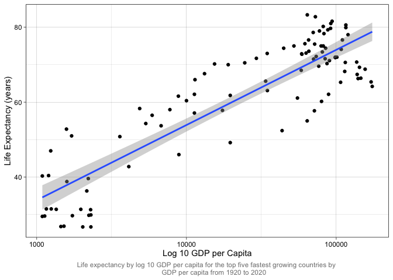

```r
top_5 %>%
  ggplot(aes(x = income_per_person_gdppercapita_ppp_inflation_adjusted, life_expectancy_years))+
  geom_point()+
  geom_smooth(method = "lm")+
  scale_x_log10()+
  labs(x = "Log 10 GDP per Capita",
       y = "Life Expectancy (years)",
       caption = "Life expectancy by log 10 GDP per capita for the top five fastest growing countries by
       GDP per capita from 1920 to 2020")+
  theme_linedraw()+
  theme(plot.caption = element_text(color = "gray50", hjust = 0.5))
```

Bottom 5 Countries

```r
gapminder_join %>%
  group_by(country) %>%
  filter(between(year, 1920, 2020)) %>%
  summarize(gdp_growth = max(income_per_person_gdppercapita_ppp_inflation_adjusted) - min(income_per_person_gdppercapita_ppp_inflation_adjusted)) %>%
arrange(gdp_growth) %>%
  head(n = 5)
```

```
## # A tibble: 5 × 2
##   country      gdp_growth
##   <chr>             <int>
## 1 Burundi             583
## 2 Somalia             687
## 3 Niger               725
## 4 Malawi              854
## 5 Sierra Leone        889
```

```r
bottom_5 <- gapminder_join %>%
  filter(country == c("Burundi","Somalia","Niger","Malawi",
                      "Sierra Leone")) %>%
  select(-population, -year)
bottom_5
```

```
## # A tibble: 101 × 3
##    country life_expectancy_years income_per_person_gdppercapita_ppp_inflation_a…
##    <chr>                   <dbl>                                           <int>
##  1 Burundi                  32.1                                             472
##  2 Burundi                  26.5                                             479
##  3 Burundi                  32.2                                             487
##  4 Burundi                  32.2                                             494
##  5 Burundi                  30.9                                             509
##  6 Burundi                  36.6                                             528
##  7 Burundi                  40.3                                             577
##  8 Burundi                  41.9                                             637
##  9 Burundi                  43.6                                             606
## 10 Burundi                  45                                               668
## # … with 91 more rows
```

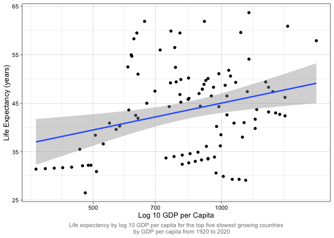

```r
bottom_5 %>%
  ggplot(aes(x = income_per_person_gdppercapita_ppp_inflation_adjusted, y = life_expectancy_years))+
  geom_point()+
  geom_smooth(method = "lm")+
  scale_x_log10()+
  labs(x = "Log 10 GDP per Capita",
       y = "Life Expectancy (years)",
       caption = "Life expectancy by log 10 GDP per capita for the top five slowest growing countries
       by GDP per capita from 1920 to 2020")+
  theme_linedraw()+
  theme(plot.caption = element_text(hjust = 0.5, color = "gray50"))
```

Comparison Between Top and Bottom 5’s

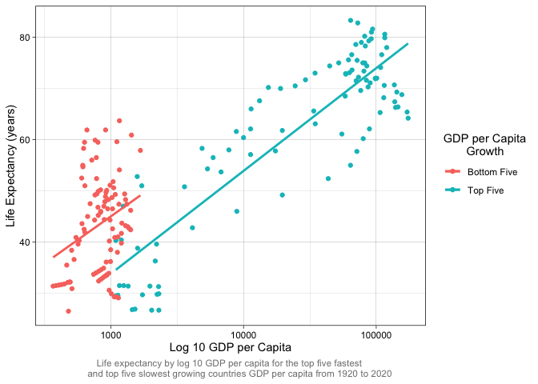

```r
top_5 %>%
  ggplot(aes(x = income_per_person_gdppercapita_ppp_inflation_adjusted, y = life_expectancy_years, color = "Top Five"))+
  geom_point()+
  geom_point(data = bottom_5, aes(x = income_per_person_gdppercapita_ppp_inflation_adjusted, y = life_expectancy_years, color = "Bottom Five"))+
  scale_x_log10()+
  geom_smooth(method = "lm", se = F)+
  geom_smooth(data = bottom_5, aes(x = income_per_person_gdppercapita_ppp_inflation_adjusted, y = life_expectancy_years, color = "Bottom Five"), method = "lm", se = F)+
  labs(x = "Log 10 GDP per Capita",
       y = "Life Expectancy (years)",
       caption = "Life expectancy by log 10 GDP per capita for the top five fastest
       and top five slowest growing countries GDP per capita from 1920 to 2020",
       color = "GDP per Capita
       Growth")+
  theme_linedraw()+
  theme(plot.caption = element_text(hjust = 0.5, color = "gray50"))
```

It seems that life expectancy scales with GDP per capita regardless of how much absolute GDP per capita is amassed since the slopes of both the bottom five and top five fastest growing countries appear to be approximately the same. However it should be noted that the data for the bottom five fastest growing countries are more spread out/inconsistent than that of the top five countries where there is a stronger correlation.